# Segunda Entrega P2

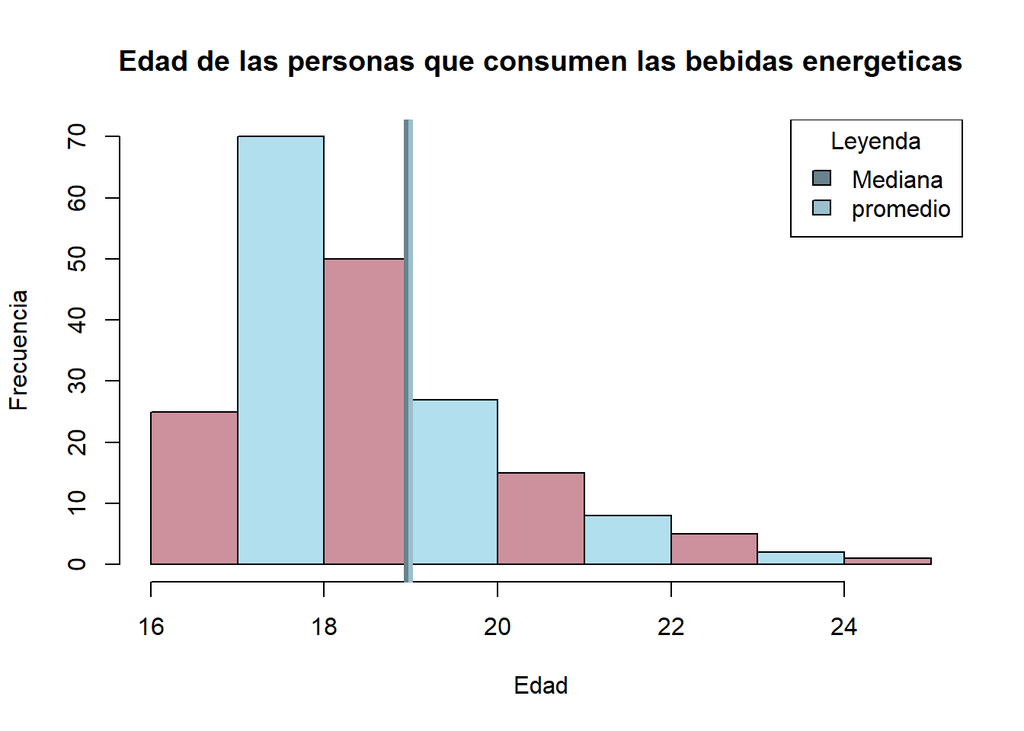

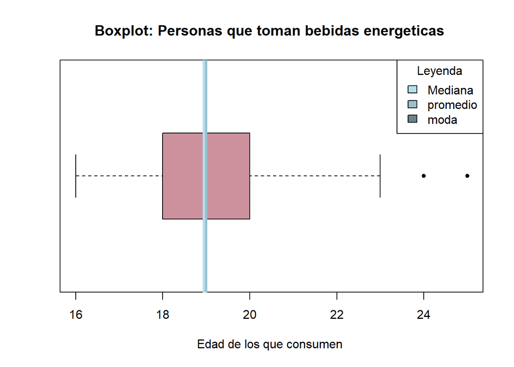

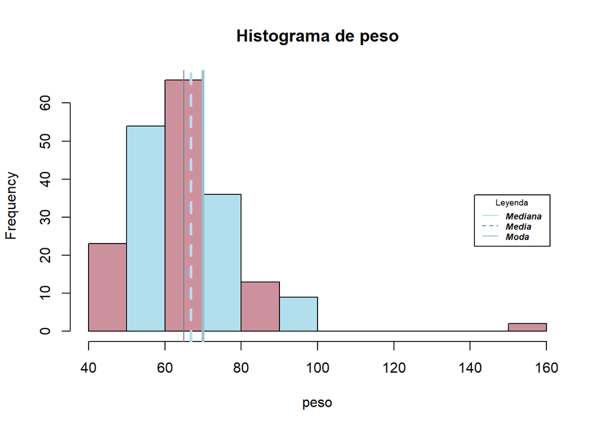

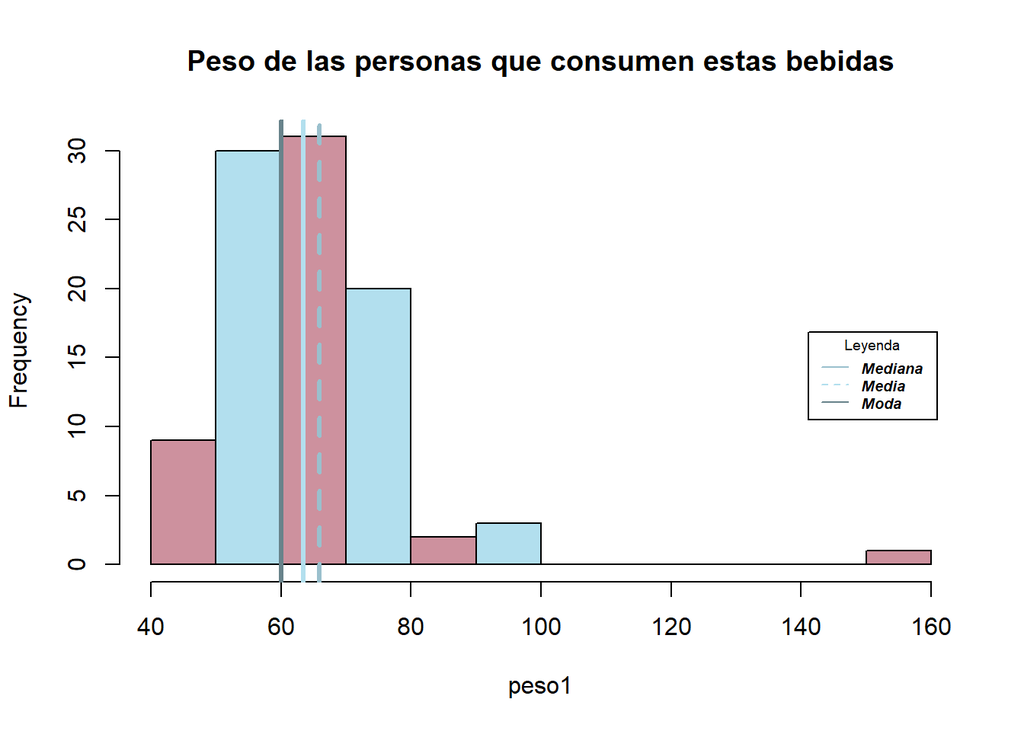

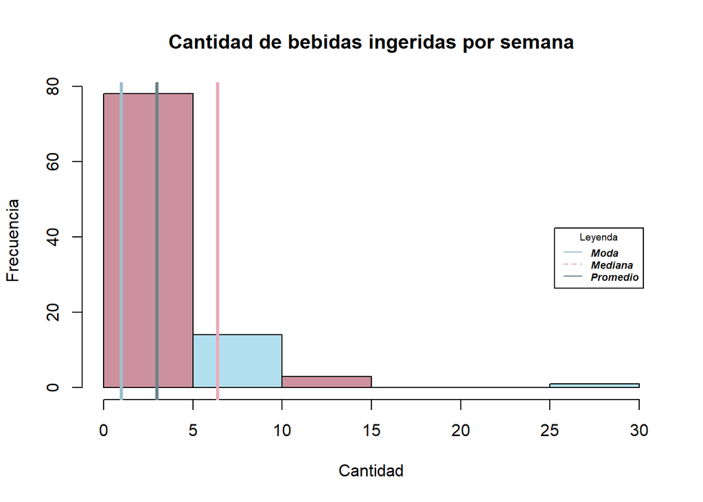

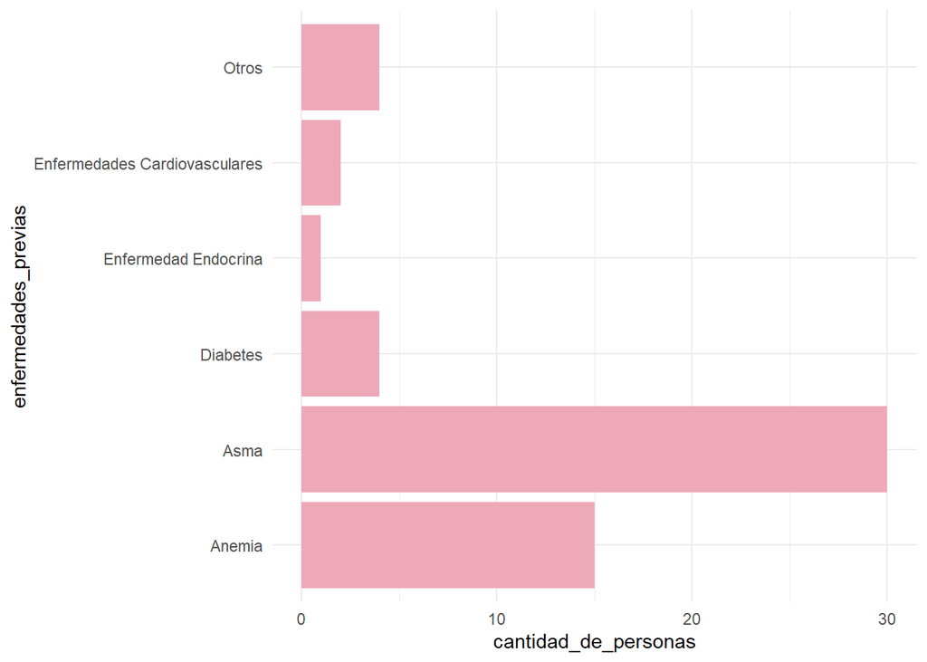

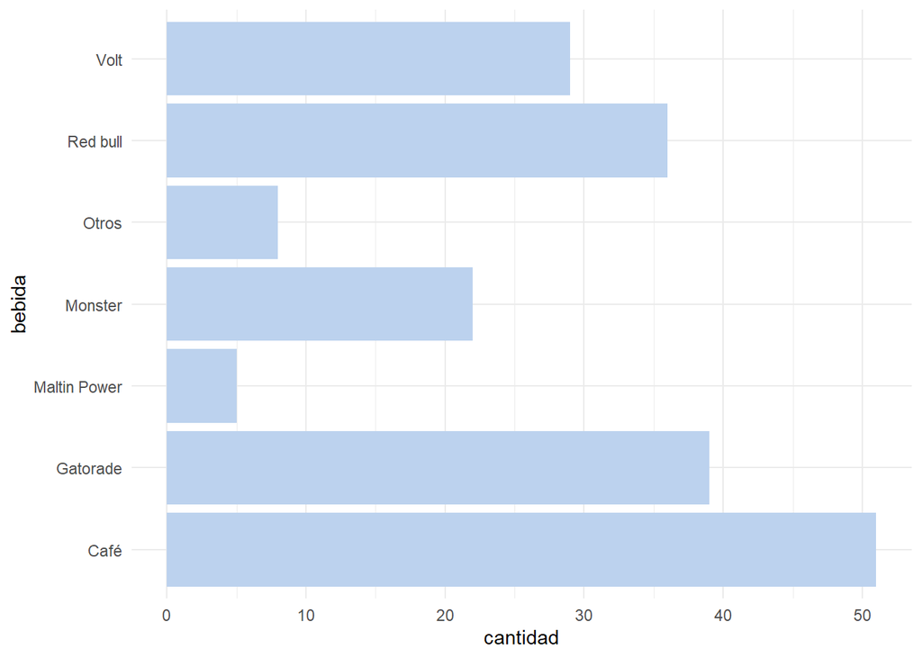

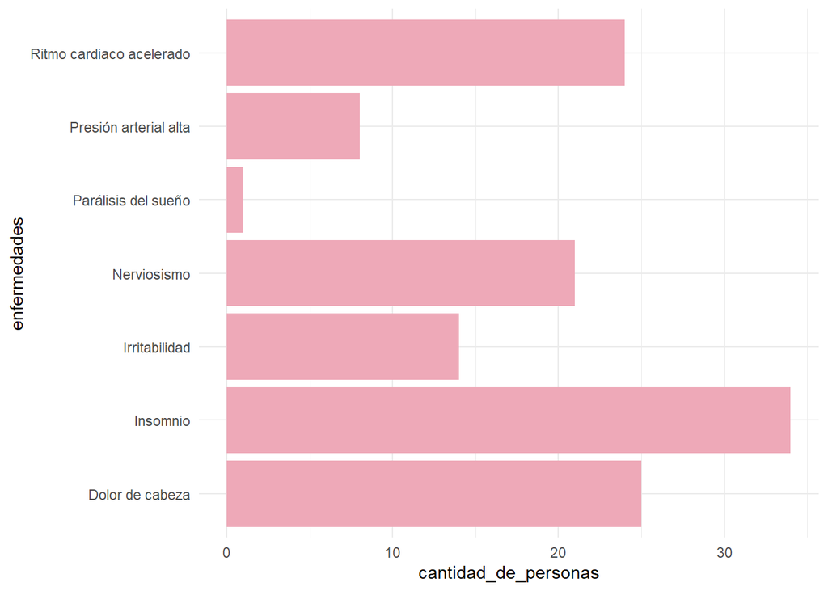

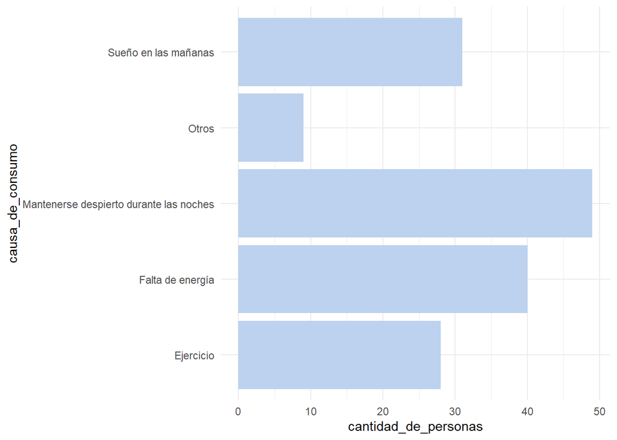

# 3.2 Interacción entre variables (Patrones)

## **3.2.1 Variable Ciclo y consumo:**

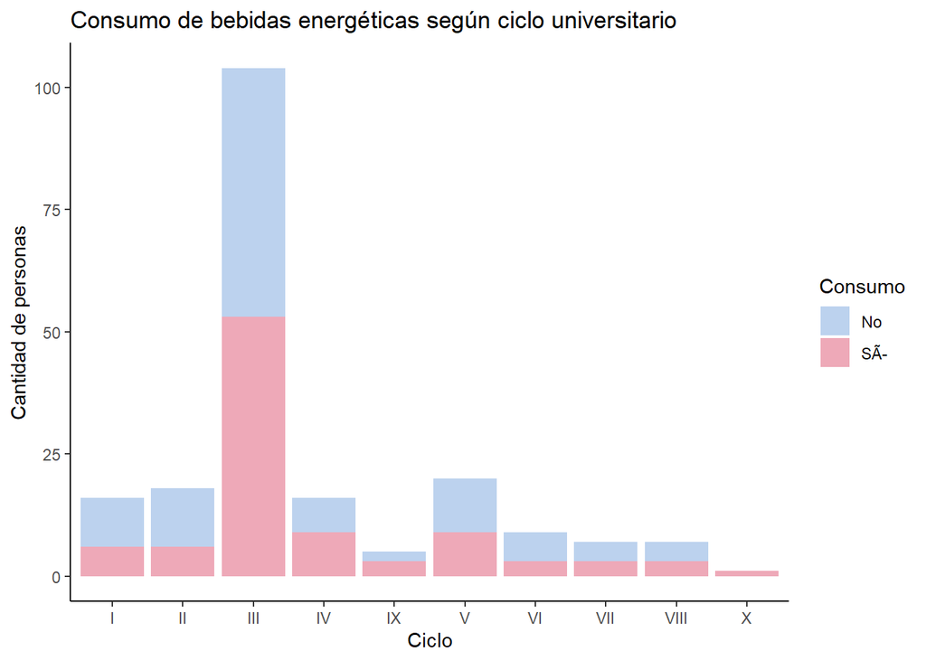

```r
modaconsumo <- data.frame(table(consumo$Consumo))
moda <- modaconsumo[which.max(modaconsumo$Freq),1]
consumo2 = consumo
consumo2$Ciclo2<-(recode(consumo2$Ciclo,"I"=1,"II"=2,"III"=3,"IV"=4,"V"=5,"VI"=6,"VII"=7,"VIII"=8,"IX"=9,"X"=10))
ggplot(consumo,aes(x = Ciclo))+geom_bar(aes(fill = Consumo))+labs(x = "Ciclo",y= "Cantidad de personas",title = "Consumo de bebidas energéticas según ciclo universitario")+scale_fill_manual(values=c("#BCD2EE", "#EEA9B8"))+theme_classic()
```

## **3.2.2 La variable cantidad vs momento**

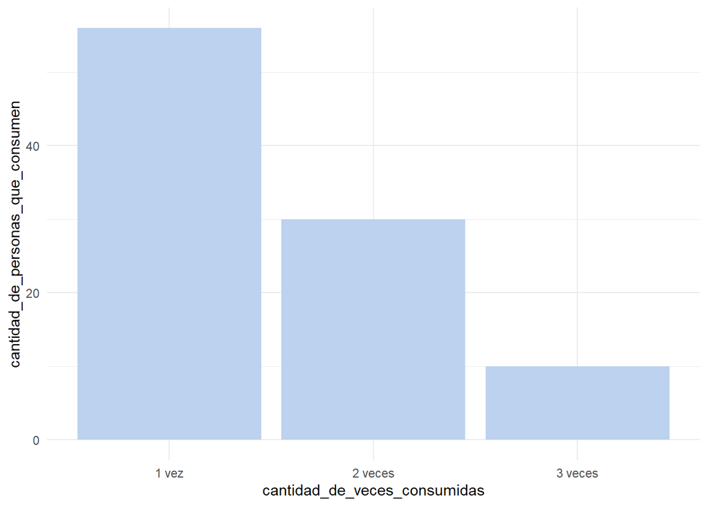

```r
ov <- 56
tv <- 30
trv <- 10
cantidad_de_personas_que_consumen  <-c(ov,tv,trv)
cantidad_de_veces_consumidas<- c("1 vez","2 veces","3 veces")
datos<- data.frame(cantidad_de_veces_consumidas=cantidad_de_veces_consumidas,cantidad_de_personas_que_consumen=cantidad_de_personas_que_consumen)
ggplot()+
  geom_bar(data=datos,
           aes(x=cantidad_de_personas_que_consumen , y=cantidad_de_veces_consumidas),
           stat = "identity",
           fill="#BCD2EE",
           position="dodge")+
  coord_flip()+
  theme_minimal()
```

Aquí,relacionamos los momentos del día marcadoscon la cantidad de veces al día. Con ello obtenemos que la mayor parte de encuestados que sí consumen bebidas energéticas lo consumen 1 vez al día, siendo la moda. Y la menor parte de encuestados lo consumen 3 veces al día (mañana, tarde y noche), lo cual no es sano.

## **3.2.3 La variable altura-peso**

## La variable altura vs peso - variable altura vs peso (Filtrado)

```r
cov(consumo$Altura,consumo$Peso)
```

```
## [1] 69.55472
```

```r
cor(consumo$Altura,consumo$Peso)
```

```
## [1] 0.5219669
```

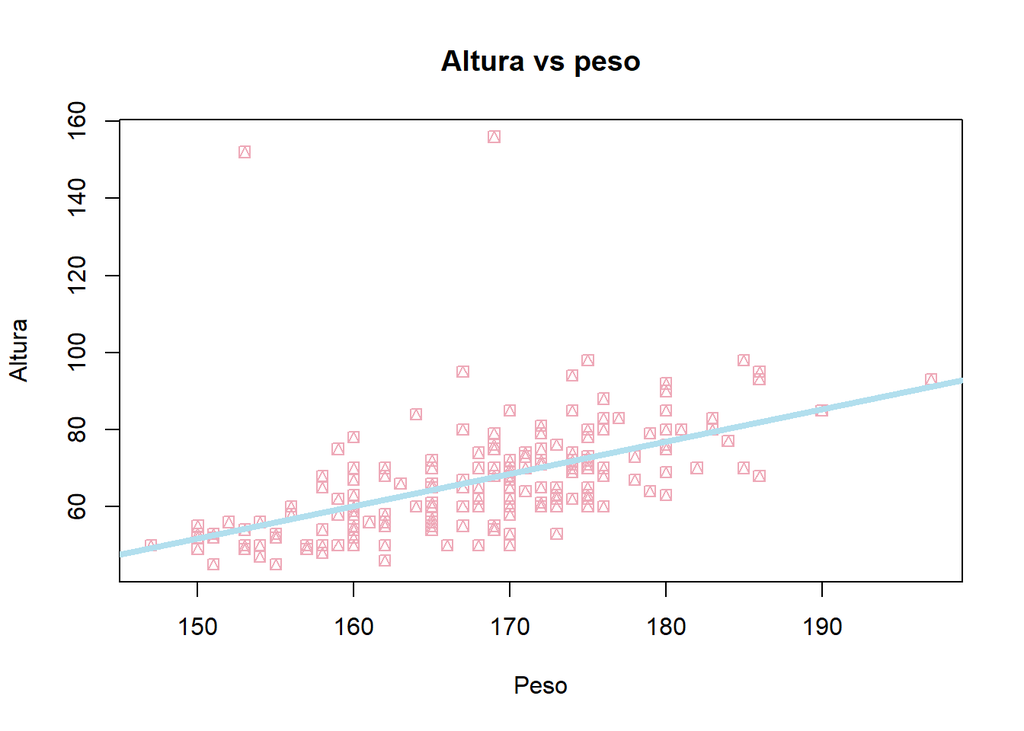

```r
plot(consumo$Altura,consumo$Peso,main = "Altura vs peso", xlab = "Peso", ylab="Altura", col="#EEA9B8",pch=14)

abline(lm(consumo$Peso ~ consumo$Altura),col="light blue2", lwd=4)
```

```r
altura_peso_modelo1<-lm(consumo$Peso ~ consumo$Altura)
summary(altura_peso_modelo1)
```

```
##
## Call:
## lm(formula = consumo$Peso ~ consumo$Altura)
##
## Residuals:
##     Min      1Q  Median      3Q     Max
## -18.548  -6.867  -0.951   3.133  97.738
##
## Coefficients:
##                 Estimate Std. Error t value Pr(>|t|)
## (Intercept)    -74.30709   16.29306  -4.561 8.86e-06 ***
## consumo$Altura   0.84032    0.09686   8.676 1.39e-15 ***
## ---
## Signif. codes:  0 '***' 0.001 '**' 0.01 '*' 0.05 '.' 0.1 ' ' 1
##
## Residual standard error: 12.52 on 201 degrees of freedom
## Multiple R-squared:  0.2724, Adjusted R-squared:  0.2688
## F-statistic: 75.27 on 1 and 201 DF,  p-value: 1.393e-15
```

- La correlación entre estas dos variables es 0.5219669 los que indica que tienen una asociación directamente proporcinaL regular
- El modelo3: y= -74 + 0.84X

*variable altura vs peso (Filtrado)*

```r
Consumo <- consumo$`¿Consumes bebidas energizantes?`
tabla_filtrada <- filter(consumo, Consumo=="SÃ")

cov(tabla_filtrada$Altura,tabla_filtrada$Peso)
```

```
## [1] 54.29934
```

```r
cor(tabla_filtrada$Altura,tabla_filtrada$Peso)
```

```
## [1] 0.4293539
```

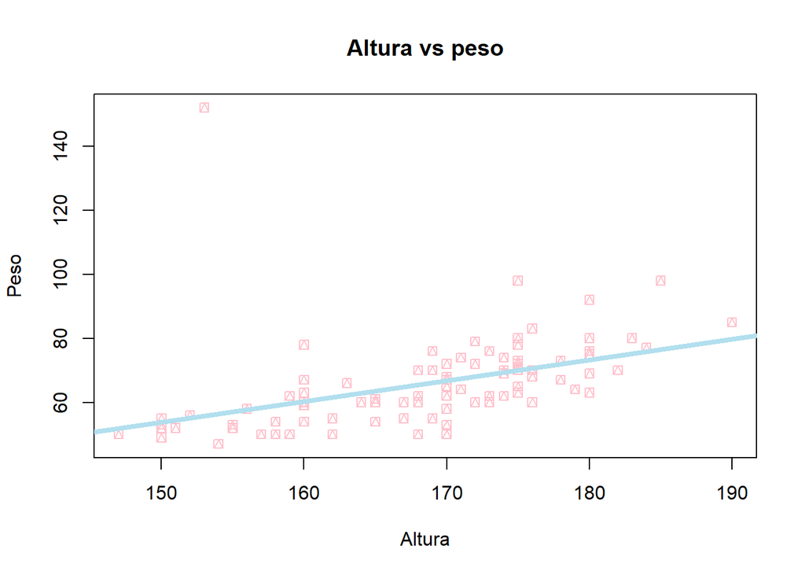

```r
plot(tabla_filtrada$Altura,tabla_filtrada$Peso,main = "Altura vs peso", xlab = "Altura", ylab="Peso", col="pink",pch=14)

abline(lm(tabla_filtrada$Peso ~ tabla_filtrada$Altura),col="light blue2", lwd=4)
```

```r
altura_peso_modelo2<-lm(tabla_filtrada$Peso ~ tabla_filtrada$Altura)
summary(altura_peso_modelo2)
```

```
##
## Call:
## lm(formula = tabla_filtrada$Peso ~ tabla_filtrada$Altura)
##
## Residuals:
##     Min      1Q  Median      3Q     Max
## -16.810  -5.508  -1.802   3.138  96.254
##
## Coefficients:
##                       Estimate Std. Error t value Pr(>|t|)
## (Intercept)           -43.8315    23.8316  -1.839    0.069 .
## tabla_filtrada$Altura   0.6508     0.1412   4.609 1.27e-05 ***
## ---
## Signif. codes:  0 '***' 0.001 '**' 0.01 '*' 0.05 '.' 0.1 ' ' 1
##
## Residual standard error: 12.57 on 94 degrees of freedom
## Multiple R-squared:  0.1843, Adjusted R-squared:  0.1757
## F-statistic: 21.24 on 1 and 94 DF,  p-value: 1.271e-05
```

- La correlación entre estas dos variables es 0.4293539los que indica que tienen una asociación directamente proporcinaL regular se observa que se redujo con relación a la correlación de la gráfioca sin filtrar
- El modelo3: y= -43 + 0.65X

# 4 Probabilidades

Nuestro objetivo gira en torno a cómo puede afectar a los alumnos de la universidad UTEC el consumo de bebidas energizantes, es por ello que trabajaremos con las variables “efectos secundarios” y “Momento”, que representa los momentos en los cuáles los encuestados consumen algún tipo de bebida. No obstante, no se puede trabajar directamente con los datos proporcionados por nuestra base de datos principal. Es por ello que, antes de hacer el respectivo análisis, debemos crear una nueva data frame, reagrupar y recategorizar variables.

Tabla 1 La variable “Momento” se encuentra en nuestra base de datos como una variable categórica, que indica en qué momentos se suele consumir al día (mañana, tarde y noche). Como lo que nos interesa es saber cuántas veces se consume y no en qué momento del día, convertiremos dicha variable en una discreta, que contenga el número de veces consumidas. La matriz “Veces” contendrá la antigua y la nueva variable “Momento”

Recategorizamos la variable categórica “Momento” a una variable discreta

```r
Veces <- tabla_filtrada %>% select(Momento) %>% mutate(veces=case_when(
                                  Momento=="Tarde, noche"~ 2,
                                  Momento=="MaÃ±ana, Tarde"~ 2,
                                  Momento=="MaÃ±ana, noche"~ 2,
                                  Momento=="MaÃ±ana, Tarde, noche" ~3,
                                  TRUE ~1 ))
```

Luego, recategorizamos las variables de efectos secundarios para convertirlas a variables discretas. El número uno (1) indica que el encuestado sí sufre de ese efecto y el cero (0) indica que no. De esta manera obtenemos 7 vectores de que contienen los efectos secundarios Recategorizando nuestras variables:

```r
ritmo_cardiaco <-tabla_filtrada %>% select(Ritmo.cardÃ.aco.acelerado)%>% mutate(Ritmo.cardÃ.aco.acelerado=case_when(
                                  Ritmo.cardÃ.aco.acelerado=="SÃ"~ 1,
                                  TRUE ~0))
nerviosismo <-tabla_filtrada %>% select(Nerviosismo)%>% mutate(Nerviosismo=case_when(
                                  Nerviosismo=="SÃ"~ 1,
                                  TRUE ~0))
irritabilidad <-tabla_filtrada %>% select(Irritabilidad)%>% mutate(Irritabilidad=case_when(
                                  Irritabilidad=="SÃ"~ 1,
                                  TRUE ~0))
insomnio <- tabla_filtrada %>% select(Insomnio)%>% mutate(Insomnio=case_when(
                                  Insomnio=="SÃ"~ 1,
                                  TRUE ~0))
otros <- tabla_filtrada %>% select(Otros)%>% mutate(Otros=case_when(
                                  Otros=="SÃ"~ 1,
                                  TRUE ~0))
dolor_cabeza <- tabla_filtrada %>% select(Dolor.de.cabeza)%>% mutate(Dolor.de.cabeza=case_when(
                                  Dolor.de.cabeza=="SÃ"~ 1,
                                  TRUE ~0))
paralisis <- tabla_filtrada %>% select(ParÃ.lisis.del.sueÃ.o)%>%   mutate(ParÃ.lisis.del.sueÃ.o=case_when(
                                  ParÃ.lisis.del.sueÃ.o=="SÃ"~ 1,
                                  TRUE ~0))
```

En un nuevo data frame, le añadiremos a la matriz “Veces” los 7 vectores columna de los efectos. Dicho data frame será llamdo “tabla_base”, el cual no ayudará para construir una segunda tabla más adelante.

```r
tabla_base <- Veces %>% mutate(ritmo_cardiaco, paralisis, nerviosismo, irritabilidad, insomnio, dolor_cabeza, otros)
tabla_base
```

| Momento | veces | Ritmo.cardÃ.aco.acelerado | ParÃ.lisis.del.sueÃ.o | Nerviosismo | Irritabilidad | Insomnio | Dolor.de.cabeza | Otros |
| --- | --- | --- | --- | --- | --- | --- | --- | --- |
| Tarde | 1 | 0 | 0 | 0 | 0 | 0 | 0 | 0 |
| Tarde, noche | 2 | 0 | 0 | 0 | 0 | 0 | 0 | 0 |
| noche | 1 | 0 | 0 | 0 | 0 | 0 | 0 | 0 |
| Mañana, Tarde, noche | 3 | 0 | 0 | 0 | 0 | 0 | 0 | 1 |
| Tarde | 1 | 0 | 0 | 0 | 0 | 0 | 0 | 0 |
| Mañana | 1 | 0 | 0 | 0 | 0 | 1 | 0 | 0 |
| noche | 1 | 0 | 0 | 0 | 0 | 1 | 1 | 0 |
| noche | 1 | 0 | 0 | 1 | 0 | 1 | 0 | 0 |
| Tarde | 1 | 1 | 0 | 0 | 0 | 0 | 0 | 0 |
| Tarde | 1 | 1 | 0 | 0 | 0 | 0 | 1 | 0 |

[output cut: 86 more lines]

Finalmente con los comandos “group_by” y “summarise” resumimos los datos en “Tabla_1”

```r
tabla1 <-tabla_base %>% group_by(veces) %>% summarise(
  "Ritmo cardíaco acelerado"=sum(Ritmo.cardÃ.aco.acelerado),
  "Parálisis del sueño"=sum(ParÃ.lisis.del.sueÃ.o),
  "Nerviosismo"=sum(Nerviosismo),
  "Irritabilidad"=sum(Irritabilidad),
  "Insomnio"=sum(Insomnio),
  "Dolor de cabeza"=sum(Dolor.de.cabeza),
  "Otros"=sum(Otros))

Tabla_1<-data.frame(t(tabla1[-1]))
colnames(Tabla_1)<-tabla1[, 1]

names(Tabla_1) <- c("1 vez", "2 veces", "3 veces")
Tabla_1<-Tabla_1 %>% mutate(Total=rowSums(Tabla_1[, 1:3]))
tabla_1<-rbind(Tabla_1, Total=colSums(Tabla_1[1:7,]))
tabla_1
```

|  | 1 vez | 2 veces | 3 veces | Total |
| --- | --- | --- | --- | --- |
| Ritmo cardíaco acelerado | 14 | 7 | 3 | 24 |
| Parálisis del sueño | 0 | 1 | 0 | 1 |
| Nerviosismo | 12 | 5 | 4 | 21 |
| Irritabilidad | 5 | 4 | 5 | 14 |
| Insomnio | 18 | 11 | 5 | 34 |
| Dolor de cabeza | 12 | 8 | 5 | 25 |
| Otros | 0 | 1 | 2 | 3 |
| Total | 61 | 37 | 24 | 122 |

Tabla 2 Para la construcción de esta nueva tabla, se vuelve a llamar a “tabla_base”, a la cual se le adiciona una columna que contenga el número de efectos secundarios que padece cada encuestado y se le asigna a “tabla2”. Esta vez, el número de efectos estará representado por rangos. Finalmente se elabora una tabla cruzada con el comando “CrossTable”.

```r
tabla2<-tabla_base %>% mutate(Num_efectos= rowSums(tabla_base[, 2:9]))

Tabla2 <- tabla2 %>% select(Num_efectos, veces) %>% mutate(Num_efectos=case_when(
                                  Num_efectos <=1 ~ "[0-1]",
                                  Num_efectos<=3 ~ "[2-3]",
                                  Num_efectos<=5 ~ "[4-5]",
                                  Num_efectos<=7 ~ "[6-7]",))
```